# Professional CV

abiyu@antexusolutions.com - twitter: @abiyugiday

2016-06-23

## Profile

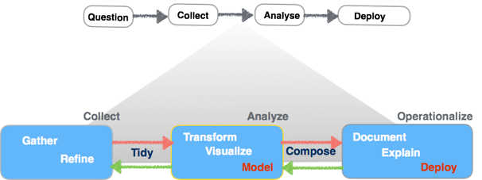

A certified Data scientist who is excited about the possibilities data and predictive analytics bring to drive better decisions that will result indepth understanding of populations, identify patterns that will reveal both weaknesses and opportunities. Data experiences include data wrangling, exploring, visualizing, developing data application and fitting statistical models to make prediction.

## Summary of Qualification

- Build predictive models that will bring to light unseen relationships in order to drive better business decisions.

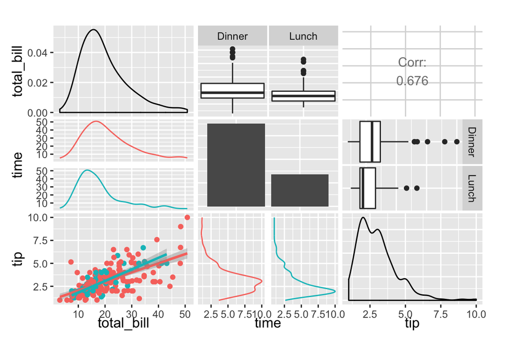

  Pairwise comparison of multivariate data
- Generate interactive visualization of data to communicate complex ideas with “clarity, precision and efficiency.”
- Acquire, prepare and explore data into shape for analytics, and arrange it in comparative perspective for enhanced decision making.
- Build interactive dashboards for ‘what-if’ analysis by manipulating key variables in the dataset to simulate and consider business scenario outcomes.
- Generate statistical models with machine learning algorithms to predict and classify data for the purpose of pattern and trend discovery.
- Operationalize model by integrating the model in a web application and/or generating API to make model logic accessible to users.

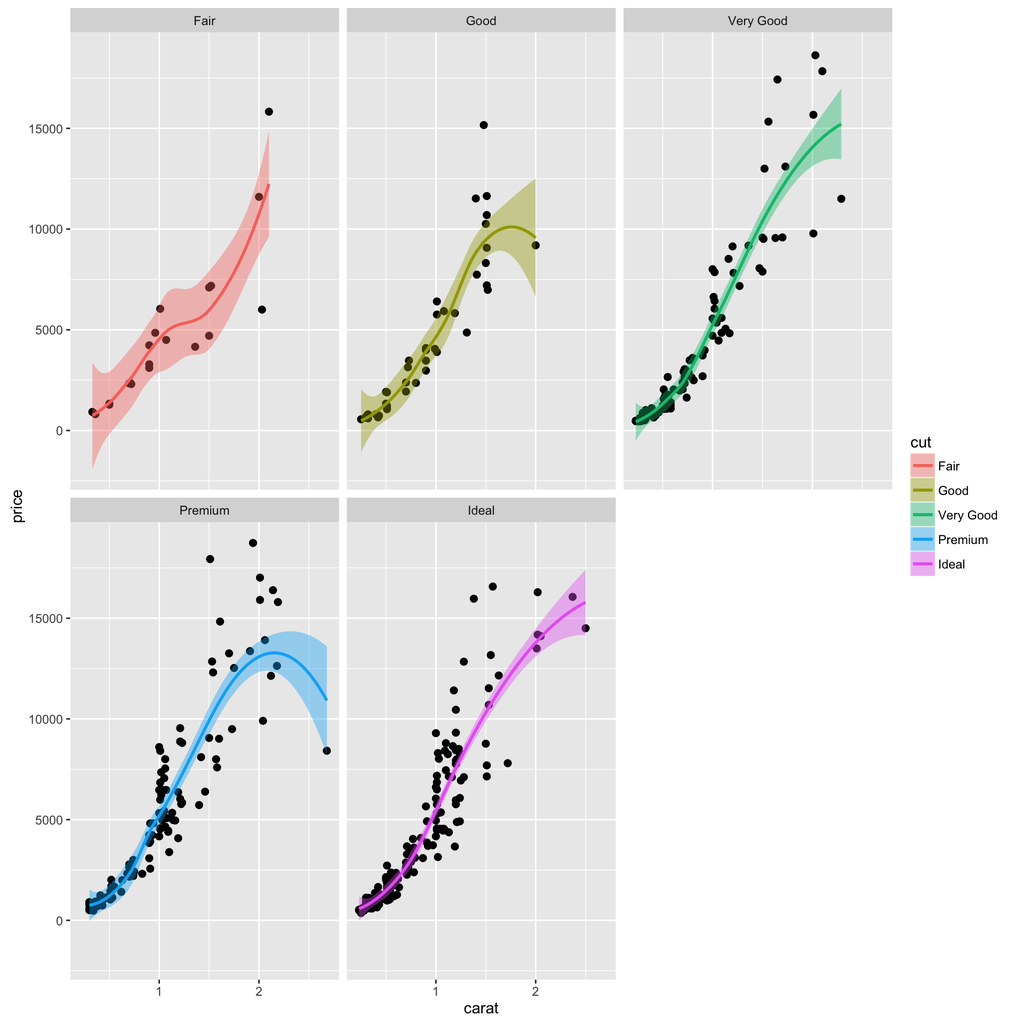

  Fittig locally weighted regression model.
- Prepare data by following proven tidy principals that will identify and impute missing values, handle outliers and engineer new features to enhance existing data for analytics.
- Generate reproducible document integrated with interactive data simulations.

## Data Projects Completed:

### Predictive Analytics:

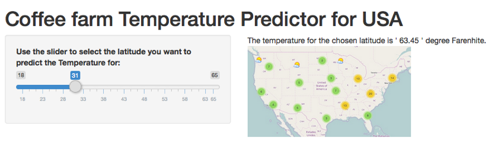

- Generated a linear regression weather predicting model for USA based on historical data from NOAA. A shiny app is developed and is deployed on shinyapps.io.

  [Weather Prediction Shiny App](https://abiyug.shinyapps.io/weatherPredict/)
- Built a model that predicts quality of human activity based on smart phone sensor data. A Random Forest Algorithm was used to train the data. Caret package was used to tune the and evaluate the mode. The mode predicted with 97% accuracy the quality of the work out for individuals.

  [Predictive Modeling App](https://github.com/abiyug/MachineLearning/blob/master/QualityMeasurmentPredictRF.Rmd)

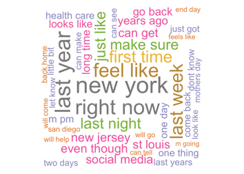

- Natural Language Processing next word predictionr newthought for English language utilizing unstructured data scrapped from news papers, twitter accounts and blogs to create the corpus. Conditional statistics applied with n-gram models to rank the words based on their respective maximum likely hood probability. A shiny apps product was developed and hosted on shinapps.io

  [NLP next word predictor](http://abiyug.github.io/2016-05-01-Next-Word-Predict-V1.1)
- A web applicatoin for City of houston crime Analysis built with shiny web framework from RStudio. The dataset ‘Crime’ is gathered from Houston Texas Police crime report from January to August 2010. The data is cleaned and arranged so that only more serious crimes (murder, Rape, robbery and aggravated assault) are considered.The data is geocoded with longitude and latitude information with Google Maps and mapped using the Leaflet map widget.

  [Interactive Crime Data Analysis App](https://abiyug.shinyapps.io/HoustonCrimeAppDemo/)

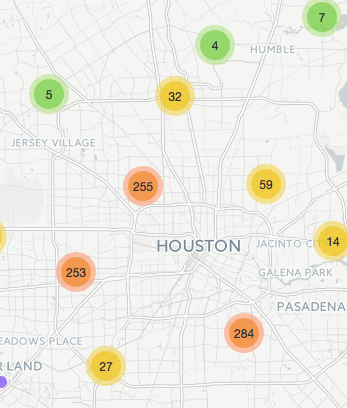

### Exploratory Data Analysis:

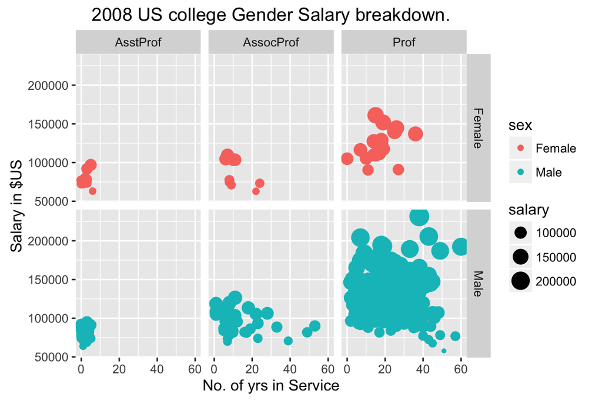

Exploratory analysis plot facet with gender and rank.

- Look into a historical college professors salaries dataset to answer a question of whether there exist gender bias when it comes to salary between male and female professors.
- Built interactive data visualization interactive data visualizationreport that explores math and science test scores to identify low performing students by gender, race and socioeconomic factors. The analysis also includes the regression model for each sub group faceted by race and socioeconomic background.

  [interactive data visualization](http://abiyug.github.io/2016-05-12-The-Signal-&-The-Noise-for)
- Used animation R package (‘gganimate`) to recreate the gapminder graph that tracks over sixty years life expectancy trends for populations by country and continent. populations by country and continent.

  [populations by country and continent](http://abiyug.github.io/2016-02-06-gganimate-with-ggplot-gapminder-03)

## Data Toolbox:

Frequently used data tools

| Tools | Description |
| --- | --- |
| R | Open source statistical programing language, to make sense of data. |
| RStudio | Integrated development environment (IDE) for R. |
| Rmarkdown | A core tool in literate statistical programming |
| Shinyapps.io | Web application hosting by RStudio |
| Shiny Dashboard | Dashboard stay layout with shiny. |
| Github | Collaboration, code managment and repository |

## Frequently used R packages:

Frequently used Rpackages

| Package | Description |
| --- | --- |
| Caret | Model training and tuning, Evaluate model performance, Variable |
| stats | R statistical functions |
| doMC | Provides a mechanism needed to execute foreach loops in parallel. |
| ggplot2 | An Implementation of the Grammar of Graphics |
| ggmap | A collection of functions to visualize spatial data and models on top of static maps |
| leaflet | Create Interactive Web Maps with the JavaScript ‘Leaflet’. |
| DT | HTML table widget using the DataTables library |
| DBI | Create connection to DBMS |
| rCharts | Interactive Charts using Polycharts.js |
| reshape2 | Flexibly restructure and aggregate data |
| qdap | Cleaning unstructured text and debugging |
| stringi | String Processing Package |
| stringr | String manipulation Package |
| tm | Text mining package |
| mgritter | Provides a mechanism for chaining commands with a new forward-pipe |
| dplyr | Provides a flexible grammar of data manipulation. |
| shiny | Web Application Framework for R |
| utils | The R Utils Package |

## Github Contributions:

- dplyr, shiny, RMySQL, purrr, beautiful-Jekyll

## Professional experiences:

**Antex Ultimate Solutions Group – Principal Consultant 07/2012 – 07/2015**

- Started the business and worked on all areas including customer management, service development, website maintenance, marketing.
- Designed and built software defined data center with VMware vSphere hypervisor and vCenter appliance. The data center hosted virtual servers, networks, storage and clients.
- Deployed several physical safety and security solutions anchored on Cisco IP interoperability and Collaboration (IPICS) systems for public sector and educational institutions. The solution bridges campus radio connected Land Mobile Radio (LMR) to video surveillance and various voice technologies including IP phones, PSTN phones and Cell phones.

**Cisco Systems – Domain Expert Telecommunication 10/1999-04/2011**

- Contributed to one of the earliest (2007-2010) commercial data analytics product for a fortune 50 company that rolled out Intelligence Platform Analysis to help customers progress to higher level of operational efficiency. The product, collected a set of macro level indicators and generated a disruption index, like FICO score, that measured customer operational effectiveness and provide benchmark comparisons for products, peers, and industry segment. Worked on several communication network projects with service providers all over the world.
- Plan, design and deploy soft switch that migrated voice TDM networks to IP networks.
- Sold Cisco service provider products and service to telecommunication companies in the EMEA. Prepared proposals, customer presentations and training materials.

## Education

- **BSEE - University of District of Columbia 05/1992**
- **Data Science Specialization Certificate - John Hopkins University Bloomberg School of Public Health/Coursera 04/2016**
- Completed ten data science specialization courses including - *Reproducible research, R programming, Getting and Cleaning Data, Exploratory Data Analysis, Statistical Inference, Regression Model, Practical Machine Learning , Developing Data products and a Capstone project on Natural Language Processing (NLP) for english language.*